# 2D-Continuous Dynamical Systems (Assignment Sheet 4)

Introduction To Chaos Applied To Systems, Processes And Products (ETSIDI, UPM)

Alfonso Allen-Perkins, Juan Carlos Bueno and Eduardo Faleiro

2025-03-13

## Introduction: Example of a 2D continuous dynamical system

Before starting the exercises, let’s analyze a simple **2D continuous dynamical system** and learn how to:

- Solve it numerically using `ode45`
- Visualize its trajectories in **phase space** using `ggquiver`

Consider the system:

$$\begin{aligned}
\dot{x} &= y \\
\dot{y} &= -p x
\end{aligned}$$

which describes a **harmonic oscillator** with a parameter $p$ controlling the oscillation frequency. To solve and visualize this system in R, follow these steps:

1. **Load required libraries:**

   ```r
   library(deSolve)
   ```

   ```r
   library(ggplot2)
   library(ggquiver)
   ```

2. **Define the system of ODEs with a parameter:**

   ```r
   harmonic_oscillator <- function(t, state, parameters) {
     x <- state[1]
     y <- state[2]
     p <- parameters["p"]

     dxdt <- y
     dydt <- -p * x

     list(c(dxdt, dydt))
   }
   ```

3. **Solve the system using `ode45` with different initial conditions:**

   ```r
   parameters <- c(p = 1)  # Set parameter p
   initial_state1 <- c(x = 1, y = 0)  # First initial condition
   initial_state2 <- c(x = -1, y = 1)  # Second initial condition
   times <- seq(0, 10, by = 0.1)

   solution1 <- ode(y = initial_state1, times = times,
                    func = harmonic_oscillator,
                    parms = parameters, method = "ode45")
   solution2 <- ode(y = initial_state2, times = times,
                    func = harmonic_oscillator,
                    parms = parameters, method = "ode45")

   solution_df1 <- as.data.frame(solution1)
   solution_df2 <- as.data.frame(solution2)
   ```

4. **Plot the phase space with two orbits using `ggplot2`:**

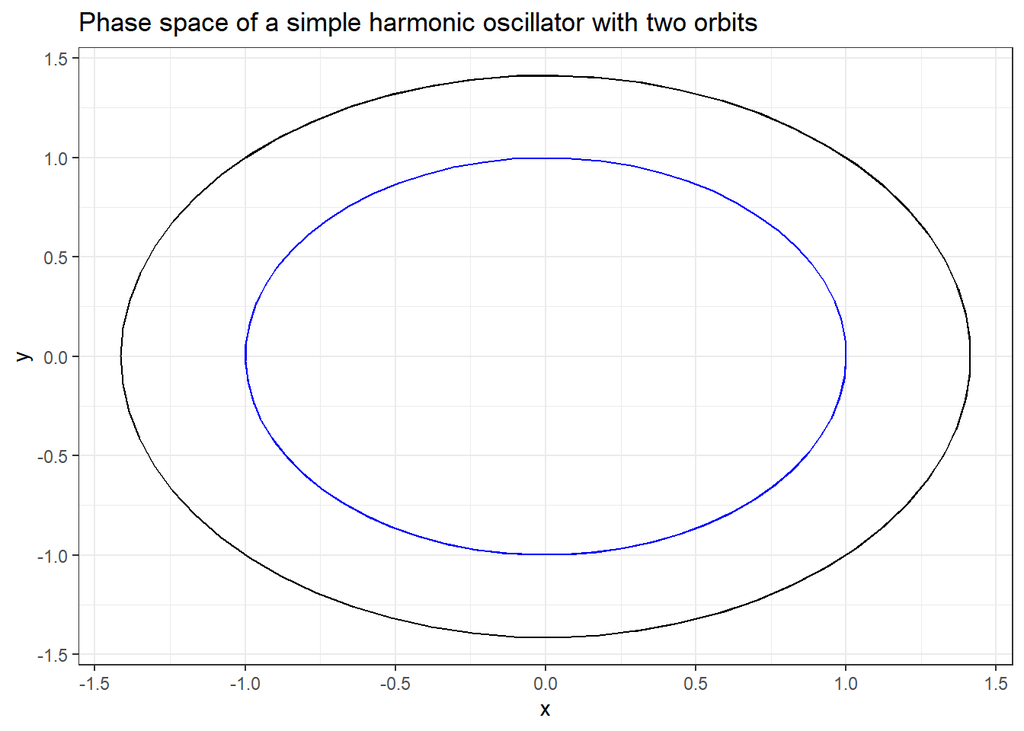

   ```r
   ggplot() +
     geom_path(data = solution_df1, aes(x = x, y = y), color = "blue") +
     geom_path(data = solution_df2, aes(x = x, y = y), color = "black") +
     xlab("x") +
     ylab("y") +
     ggtitle("Phase space of a simple harmonic oscillator with two orbits") +
     theme_bw()
   ```

5. **Visualizing the vector field with `ggquiver` along with the orbits:**

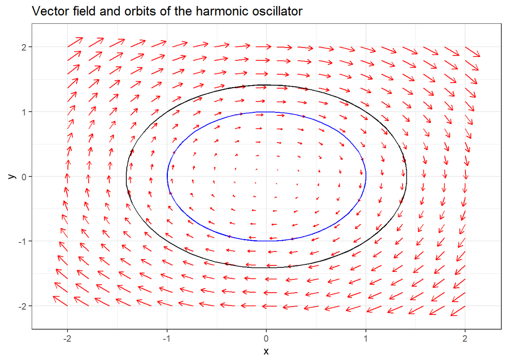

   ```r
   grid <- expand.grid(x = seq(-2, 2, length.out = 20), y = seq(-2, 2, length.out = 20))
   p_value <- 1
   grid$dx <- grid$y
   grid$dy <- -p_value * grid$x

   ggplot() +
     geom_quiver(data = grid, aes(x = x, y = y, u = dx, v = dy), color = "red", scale = 0.2) +
     geom_path(data = solution_df1, aes(x = x, y = y), color = "blue") +
     geom_path(data = solution_df2, aes(x = x, y = y), color = "black") +
     xlab("x") +
     ylab("y") +
     ggtitle("Vector field and orbits of the harmonic oscillator") +
     theme_bw()
   ```

6. **Visualizing the nullclines along with their vector fields with `ggquiver`:**

**Nullclines** are curves in the phase plane along which either $\dot{x} = 0$ or $\dot{y} = 0$. For our system:

- The $x$-nullcline (where $\dot{x} = 0$) is given by $y = 0$.
- The $y$-nullcline (where $\dot{y} = 0$) is given by $x = 0$.

The intersection of these nullclines occurs at the equilibrium point $(0,0)$.

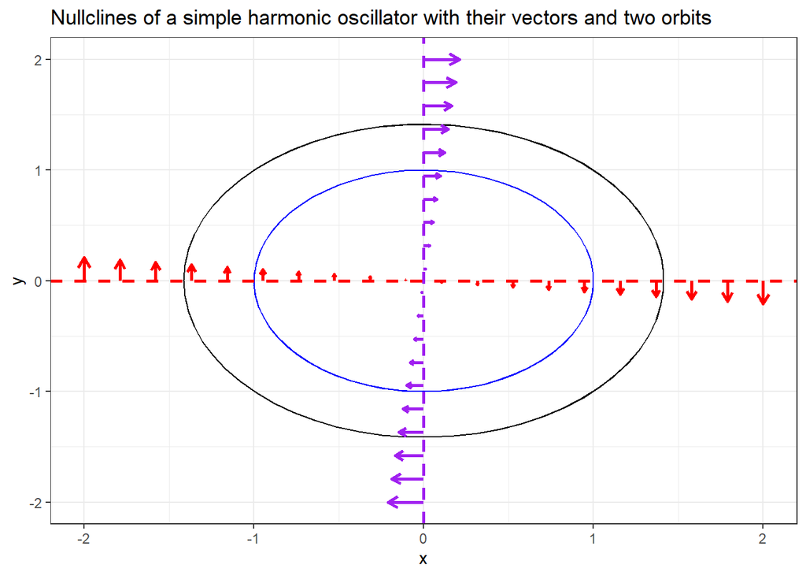

```r
grid_nullcline_x <- expand.grid(x = 0, y = seq(-2, 2, length.out = 20))
grid_nullcline_x$dx <- grid_nullcline_x$y
grid_nullcline_x$dy <- -parameters["p"] * grid_nullcline_x$x

grid_nullcline_y <- expand.grid(x = seq(-2, 2, length.out = 20), y = 0)
grid_nullcline_y$dx <- grid_nullcline_y$y
grid_nullcline_y$dy <- -parameters["p"] * grid_nullcline_y$x

ggplot() +
   geom_path(data = solution_df1, aes(x = x, y = y), color = "blue") +
   geom_path(data = solution_df2, aes(x = x, y = y), color = "black") +
   geom_vline(xintercept = 0, color = "purple", linetype = "dashed", linewidth = 1) +
   geom_hline(yintercept = 0, color = "red", linetype = "dashed", linewidth = 1) +
   geom_quiver(data = grid_nullcline_x, aes(x = x, y = y, u = dx, v = dy),
           color = "purple", linewidth = 1) +
   geom_quiver(data = grid_nullcline_y, aes(x = x, y = y, u = dx, v = dy),
           color = "red", linewidth = 1) +
   xlab("x") +
   ylab("y") +
   ggtitle("Nullclines of a simple harmonic oscillator with their vectors and two orbits") +
   theme_bw()
```

## Exercise 1: Solving a linear system with `ode45`

Using the `ode45` command, solve the linear system:

$$\begin{aligned}
\dot{x} &= -a x \\
\dot{y} &= a x - b y
\end{aligned}$$

for $a = 2$, $b = 3$, and initial conditions $x(0) = 1$, $y(0) = 1$. Try different parameter values and initial conditions. Plot the **phase space trajectory**.

## Exercise 2: Harmonic oscillator

Consider the harmonic oscillator:

$$\ddot{x} + \omega_0^2 x = 0$$

with initial conditions $x(0) = A$, $\dot{x}(0) = 0$, where $\omega_0^2 = k/m$, with $k$ as the spring constant and $m$ the mass.

- Rewrite the system as a **2D continuous dynamical system** in terms of $x_1 = x$ and $x_2 = \dot{x}$.
- Use `ggquiver` to **sketch the phase space**.
- Find the **fixed points**.
- Solve using `ode45` and **plot the trajectories** in phase space for different values of $A$.

## Exercise 3: Non-linear pendulum

The non-linear pendulum equation is:

$$\ddot{x} + \omega_0^2 \sin(x) = 0$$

where $\omega_0^2 = g/L$, with $g$ as the gravity acceleration and $L$ as the length of the rope. The variable $x$ represents the **angle with the vertical**.

Perform the **same calculations** as in Exercise 2 (2D system, phase space, fixed points, numerical solution, and trajectory plots).

## Exercise 4: Damped oscillator

Consider the damped oscillator:

$$\ddot{x} + 2\gamma \dot{x} + \omega_0^2 x = 0$$

with initial conditions $x(0) = A$, $\dot{x}(0) = 0$.

- Rewrite as a **2D continuous dynamical system**.
- Use `ggquiver` to **sketch the phase portrait**.
- Find the **fixed points**.
- Solve using `ode45` and **plot trajectories** in phase space for different values of $A$.

## Exercise 5: Damped non-Linear pendulum

Compare the results of **Exercise 4** with the **damped non-linear pendulum**, given by:

$$\ddot{x} + 2\gamma \dot{x} + \omega_0^2 \sin(x) = 0$$

Perform the same **phase space analysis and numerical solution**.

## Exercise 6: Van der Pol oscillator

Consider the **Van der Pol oscillator**:

$$\begin{aligned}
\dot{x} &= y \\
\dot{y} &= -\mu y (x^2 - 1) - x
\end{aligned}$$

- Use `ggquiver` to **sketch the phase space**.
- Solve with `ode45` for $\mu = 2$ and $x(0) = 0.1$, $y(0) = 0.1$.

## Exercise 7: The Lotka-Volterra flow

Consider the **Lotka-Volterra predator-prey model** defined by:

$$\begin{aligned}
\dot{x} &= \alpha x - \beta x y \\
\dot{y} &= \delta x y - \gamma y
\end{aligned}$$

where $\alpha, \beta, \gamma, \delta$ are **positive constants**.

1. **Use typical parameter values**, such as:
   - $\alpha = 1.1, \beta = 0.4, \gamma = 0.4, \delta = 0.1$
   - $\alpha = 0.5, \beta = 0.2, \gamma = 0.3, \delta = 0.15$
2. **Try different initial conditions**, such as:
   - $x_0 = 10, y_0 = 5$ (moderate prey, low predator)
   - $x_0 = 30, y_0 = 10$ (higher prey and predator populations)
3. **Draw the phase portrait**.
4. **Plot some solution trajectories** for different initial values.
5. **Analyze how changing parameters affect the system’s behavior.**

## Exercise 8: RLC circuit

Consider an **RLC series circuit** driven by a constant voltage source $\varepsilon$. The circuit follows the differential equation:

$$L \frac{d^2 i}{dt^2} + R \frac{d i}{dt} + \frac{1}{C} i = \frac{d \varepsilon}{dt}$$

where $i(t) = \dot{q}$ is the current at time $t$ and $q(t)$ is the charge in the capacitor at time $t$. Since $\varepsilon$ is constant, the **equivalent 2D dynamical system** is given by:

$$\begin{aligned}
\dot{x} &= y \\
\dot{y} &= - \frac{R}{L} y - \frac{1}{LC} x
\end{aligned}$$

where $x = i$ and $y = \frac{d i}{dt}$. Consider the parameter values:

$$\frac{R}{2L} = 2, \quad \frac{1}{LC} = 1, \quad \frac{\varepsilon}{L} = 1$$

and the initial conditions:

$$i(0) = 0, q(0)=0, \frac{d i}{dt}(0) = \frac{\varepsilon}{L} =1$$

- Solve using `ode45` for $x(0) = 0$ and $y(0) = 1$ over the interval $t \in [0,10]$.
- Compare the numerical solution with the **analytical solution** by plotting $i(t)$ vs. $t$.

## Exercise 9: RLC circuit with oscillations

Now, modify the parameters to:

$$\frac{R}{2L} = 1, \quad \frac{1}{LC} = 2, \quad \frac{\varepsilon}{L} = 1$$

The RLC circuit **oscillates** in this case.

- Solve using `ode45` for $i(0) = 0$ and $\frac{di}{dt}(0) = 1$ in $t \in [0,10]$.
- Compare with the **analytical solution**.

## Exercise 10: Nonlinear System from Strogatz (Ex. 6.3.2)

Consider the system:

$$\begin{aligned}
\dot{x} & = -y + a x (x^2 + y^2) \\
\dot{y} & = +x + a y (x^2 + y^2)
\end{aligned}$$

- Use `ggquiver` to **sketch the phase portrait** for $a < 0$, $a = 0$, and $a > 0$.
- Draw some **trajectories** for all values of $a$.

**Note:** Ensure that your plots use sufficient iterations and data points to observe the system’s long-term behavior.